# R Notebook

```r
library(broom)
```

ALPHA VALUE TO REJECT NULL HYPOTHESES = 0.05

```r
telecoms_churn <- read_excel("telecomms_churn.xlsx")

glimpse(telecoms_churn)
```

```
Rows: 7,043
Columns: 12
$ customerID      <chr> "7590-VHVEG", "5575-GNVDE", "3668-QPYBK", "7795-CFOCW", "9237-HQITU", "9305-CDSKC", "1452-KIOVK", "6713-OKOMC", "7892-POOKP", "6...
$ gender          <chr> "Female", "Male", "Male", "Male", "Female", "Female", "Male", "Female", "Female", "Male", "Male", "Male", "Male", "Male", "Male"...
$ SeniorCitizen   <dbl> 0, 0, 0, 0, 0, 0, 0, 0, 0, 0, 0, 0, 0, 0, 0, 0, 0, 0, 0, 0, 1, 0, 0, 0, 0, 0, 0, 0, 0, 0, 1, 1, 0, 0, 1, 0, 0, 0, 0, 0, 0, 0, 0,...
$ Partner         <chr> "Yes", "No", "No", "No", "No", "No", "No", "No", "Yes", "No", "Yes", "No", "Yes", "No", "No", "Yes", "No", "No", "Yes", "No", "N...
$ Dependents      <chr> "No", "No", "No", "No", "No", "No", "Yes", "No", "No", "Yes", "Yes", "No", "No", "No", "No", "Yes", "No", "Yes", "Yes", "No", "N...
$ tenure          <dbl> 1, 34, 2, 45, 2, 8, 22, 10, 28, 62, 13, 16, 58, 49, 25, 69, 52, 71, 10, 21, 1, 12, 1, 58, 49, 30, 47, 1, 72, 17, 71, 2, 27, 1, 1...
$ PhoneService    <chr> "No", "Yes", "Yes", "No", "Yes", "Yes", "Yes", "No", "Yes", "Yes", "Yes", "Yes", "Yes", "Yes", "Yes", "Yes", "Yes", "Yes", "Yes"...
$ InternetService <chr> "DSL", "DSL", "DSL", "DSL", "Fiber optic", "Fiber optic", "Fiber optic", "DSL", "Fiber optic", "DSL", "DSL", "No", "Fiber optic"...
$ Contract        <chr> "Month-to-month", "One year", "Month-to-month", "One year", "Month-to-month", "Month-to-month", "Month-to-month", "Month-to-mont...
$ MonthlyCharges  <dbl> 29.85, 56.95, 53.85, 42.30, 70.70, 99.65, 89.10, 29.75, 104.80, 56.15, 49.95, 18.95, 100.35, 103.70, 105.50, 113.25, 20.65, 106....
$ TotalCharges    <dbl> 29.85, 1889.50, 108.15, 1840.75, 151.65, 820.50, 1949.40, 301.90, 3046.05, 3487.95, 587.45, 326.80, 5681.10, 5036.30, 2686.05, 7...
$ Churn           <chr> "No", "No", "Yes", "No", "Yes", "Yes", "No", "No", "Yes", "No", "No", "No", "No", "Yes", "No", "No", "No", "No", "Yes", "No", "Y...
```

```r
unique(telecoms_churn$Contract)
```

```
[1] "Month-to-month" "One year"       "Two year"
```

```r
unique(telecoms_churn$SeniorCitizen)
```

```
[1] 0 1
```

```r
unique(telecoms_churn$InternetService)
```

```
[1] "DSL"         "Fiber optic" "No"
```

```r
telecoms_clean <- telecoms_churn %>%
  clean_names() %>%
  mutate(churn = ifelse(churn == "No", FALSE, TRUE),
         partner = ifelse(partner == "No", FALSE, TRUE),
         dependents = ifelse(dependents == "No", FALSE, TRUE),
         phone_service = ifelse(phone_service == "No", FALSE, TRUE),
         senior_citizen = ifelse(senior_citizen == 0, FALSE, TRUE)) %>%
  select(-customer_id) %>%
  mutate(contract = as.factor(contract),
         internet_service = as.factor(internet_service))
```

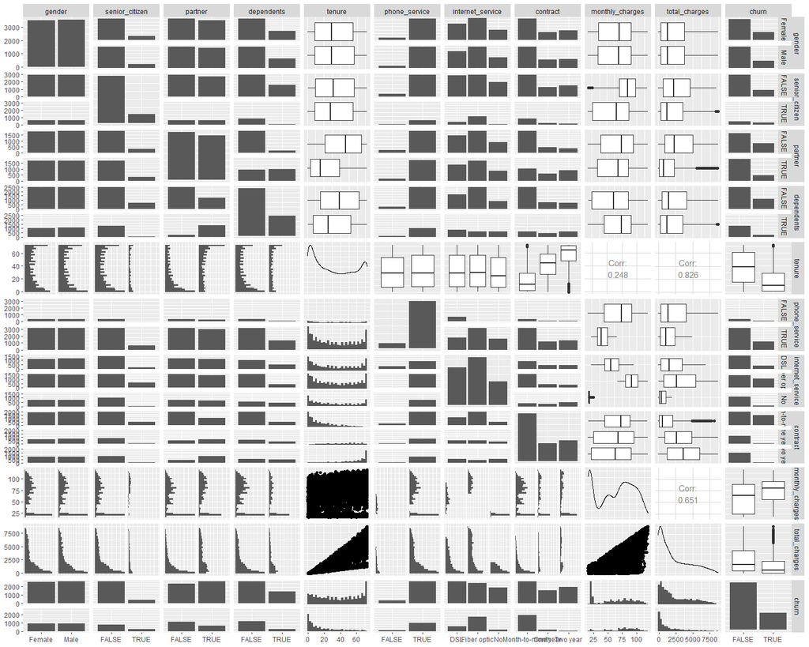

```r
ggpairs(telecoms_clean)
```

```r
beep(1)
```

3. Creating three seperate single predictor logistic regression models. The three most promising predictors in the ggpairs graph were senior_citizen, tenure, and phone service.

```r
telecom_mod1a <- glm(churn ~ senior_citizen,
                     data = telecoms_clean,
                     family = binomial(link = "logit"))

telecom_mod1b <- glm(churn ~ tenure,
                     data = telecoms_clean,
                     family = binomial(link = "logit"))

telecom_mod1c <- glm(churn ~ phone_service,
                     data = telecoms_clean,
                     family = binomial(link = "logit"))
```

checking to see whether the coefficients of the models are statistically significant.

```r
summary(telecom_mod1a)
```

```
Call:
glm(formula = churn ~ senior_citizen, family = binomial(link = "logit"),
    data = telecoms_clean)

Deviance Residuals:
    Min       1Q   Median       3Q      Max
-1.0385  -0.7339  -0.7339   1.3230   1.6992

Coefficients:
                   Estimate Std. Error z value Pr(>|z|)
(Intercept)        -1.17439    0.03065  -38.31   <2e-16 ***
senior_citizenTRUE  0.83852    0.06739   12.44   <2e-16 ***
---
Signif. codes:  0 ‘***’ 0.001 ‘**’ 0.01 ‘*’ 0.05 ‘.’ 0.1 ‘ ’ 1

(Dispersion parameter for binomial family taken to be 1)

    Null deviance: 8150.1  on 7042  degrees of freedom
Residual deviance: 8001.2  on 7041  degrees of freedom
AIC: 8005.2

Number of Fisher Scoring iterations: 4
```

p value of coefficient is <2e-16. This is lower than alpha, and we can reject the null hypothesis. Coefficient is statistically significant.

```r
summary(telecom_mod1b)
```

[output not shown]

```r
summary(telecom_mod1c)
```

```
Call:
glm(formula = churn ~ phone_service, family = binomial(link = "logit"),
    data = telecoms_clean)

Deviance Residuals:
    Min       1Q   Median       3Q      Max
-0.7883  -0.7883  -0.7883   1.6249   1.6669

Coefficients:
                  Estimate Std. Error z value Pr(>|z|)
(Intercept)       -1.10253    0.08852 -12.455   <2e-16 ***
phone_serviceTRUE  0.09312    0.09294   1.002    0.316
---
Signif. codes:  0 ‘***’ 0.001 ‘**’ 0.01 ‘*’ 0.05 ‘.’ 0.1 ‘ ’ 1

(Dispersion parameter for binomial family taken to be 1)

    Null deviance: 8150.1  on 7042  degrees of freedom
Residual deviance: 8149.1  on 7041  degrees of freedom
AIC: 8153.1

Number of Fisher Scoring iterations: 4
```

p value of coefficient is 0.316. This is higher than alpha, and we can’t reject the null hypothesis. Coefficient is not statistically significant.

Making another single predictor model using contract

```r
telecom_mod1d
```

```
Call:  glm(formula = churn ~ contract, family = binomial(link = "logit"),
    data = telecoms_clean)

Coefficients:
     (Intercept)  contractOne year  contractTwo year
         -0.2937           -1.7698           -3.2418

Degrees of Freedom: 7042 Total (i.e. Null);  7040 Residual
Null Deviance:      8150
Residual Deviance: 6763     AIC: 6769
```

p values of coefficients are both <2e-16. This is lower than alpha, and we can reject the null hypothesis. Coefficients are statistically significant.

plotting a ROC curve for each of the classifiers. Going to put them all on same axes.

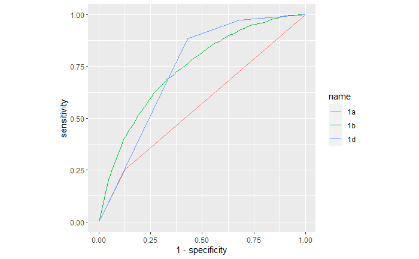

Eugh…. 1a is baaad… 1b and 1d are eh

Let’s look at AUC values

```r
auc_1a <- auc(roc_object1a)
auc_1b <- auc(roc_object1b)
auc_1d <- auc(roc_object1d)

auc_1a
```

```
Area under the curve: 0.563
```

```r
auc_1b
```

```
Area under the curve: 0.7399
```

```r
auc_1d
```

```
Area under the curve: 0.7391
```

The AUC value is highest for mod1b, but mod1d is pretty similar. mod1a is barely better than random.

5. Performing cross validation to check how representative the AUC values calculated above will be for unseen data.

```r
#making the churn and senior_citizen columns factors, so that they're compatibe with caret package.
telecoms_cleaner <- telecoms_clean %>%
  mutate(churn = as_factor(ifelse(churn, "t", "f"))) %>%
  mutate(senior_citizen = as_factor(ifelse(senior_citizen, "t", "f")))

train_control <- trainControl(method = "repeatedcv",
                              number = 10,
                              repeats = 100,
                              savePredictions = TRUE,
                              classProbs = TRUE,
                              summaryFunction = twoClassSummary)

model1a <- train(churn ~ senior_citizen,
                 data = telecoms_cleaner,
                 trControl = train_control,
                 method = "glm",
                 family = binomial(link = "logit"))
```

```
The metric "Accuracy" was not in the result set. ROC will be used instead.
```

```r
model1b <- train(churn ~ tenure,
                 data = telecoms_cleaner,
                 trControl = train_control,
                 method = "glm",
                 family = binomial(link = "logit"))
```

```
The metric "Accuracy" was not in the result set. ROC will be used instead.
```

```r
model1d <- train(churn ~ contract,
                 data = telecoms_cleaner,
                 trControl = train_control,
                 method = "glm",
                 family = binomial(link = "logit"))
```

```
The metric "Accuracy" was not in the result set. ROC will be used instead.
```

|  | parameter | ROC | Sens | Spec | ROCSD | SensSD | SpecSD |
| --- | --- | --- | --- | --- | --- | --- | --- |
| 1 | none | 0.5629809 | 1 | 0 | 0.01654764 | 0 | 0 |

AUC value (labelled as ROC) is 0.563. Barely better than a random guess

|  | parameter | ROC | Sens | Spec | ROCSD | SensSD | SpecSD |
| --- | --- | --- | --- | --- | --- | --- | --- |
| 1 | none | 0.739835 | 0.9907804 | 0.02797228 | 0.01904084 | 0.01790056 | 0.06894539 |

AUC value is 0.740

```r
summary(model1d)
```

```
Call:
NULL

Deviance Residuals:
   Min      1Q  Median      3Q     Max
-1.056  -1.056  -0.489   1.304   2.670

Coefficients:
                   Estimate Std. Error z value Pr(>|z|)
(Intercept)        -0.29371    0.03248  -9.044   <2e-16 ***
`contractOne year` -1.76980    0.08857 -19.983   <2e-16 ***
`contractTwo year` -3.24180    0.14998 -21.614   <2e-16 ***
---
Signif. codes:  0 ‘***’ 0.001 ‘**’ 0.01 ‘*’ 0.05 ‘.’ 0.1 ‘ ’ 1

(Dispersion parameter for binomial family taken to be 1)

    Null deviance: 8150.1  on 7042  degrees of freedom
Residual deviance: 6763.3  on 7040  degrees of freedom
AIC: 6769.3

Number of Fisher Scoring iterations: 6
```

| odds |
| --- |
| 0.2972334 |

with a tenure of 32 years, the odds of a customer churning are about 1 to 3.

lets see what the odds factor is for a change of -20 years, and a tenure of 12 years

| estimate |
| --- |
| 2.171339 |

That’s an odds factor of 2.17

| estimate |
| --- |
| 0.6453945 |

That’s an odds of about 2 to 3. Which means that a customer is twice as likely to churn if they’ve had a tenure of 12 years.

```r
unique(telecoms_clean$contract)
```

```
[1] Month-to-month One year       Two year
Levels: Month-to-month One year Two year
```

```r
b_contract_1year <- tidy(telecom_mod1d) %>%
  filter(term == "contractOne year") %>%
  select(estimate)

odds_ratio_1_year <- exp(b_contract_1year)

b_contract_2year <- tidy(telecom_mod1d) %>%
  filter(term == "contractTwo year") %>%
  select(estimate)

odds_ratio_2_year <- exp(b_contract_2year)

odds_ratio_1_year
```

| estimate |
| --- |
| 0.1703678 |

```r
odds_ratio_2_year
```

| estimate |
| --- |
| 0.03909333 |